# 数学建模

### 模型知识点

### 评价模型-评价模型-TOPSIS

**Wang Haihua**

🚅 🚋😜 🚑 🚔

# TOPSIS方法

C.L.Hwang 和 K.Yoon 于1981年首次提出 TOPSIS (全称：Technique for Order Preference by Similarity to an Ideal Solution)。

TOPSIS 法是一种常用的组内综合评价方法，能充分利用原始数据的信息，其结果能精确地反映各评价方案之间的差距。

基本过程为基于归一化后的原始数据矩阵，采用余弦法找出有限方案中的**最优方案和最劣方案**，然后分别计算各评价对象与最优方案和最劣方案间的距离，获得各评价对象与最优方案的相对接近程度，以此作为评价优劣的依据。

该方法对数据分布及样本含量没有严格限制，数据计算简单易行。

为了客观地评价我国研究生教育的实际状况和各研究生院的教学质量，国务院学位委员会办公室组织过一次研究生院的评估。为了取得经验，先选5所研究生院，收集有关数据资料进行了试评估，下表是所给出的部分数据：

[figure not shown]

**Step1**: 指标的筛选，经过观察，该数据不需要进行指标的筛选。

**Step2**: 指标的一致化处理。通过分析，我们知道：

- 人均专著，越多越好（极大型指标）
- 科研经费，越多越好（极大型指标）
- 逾期毕业率，越小越好（极小型指标）
- 生师比，过大过小都不好（区间型指标）

设研究生院的生师比最佳区间为$[5,6]$，在最佳区间内生师比得分为1 ，如果生师比小于2或者大于12都是0分，在其他的区间都按照线性关系进行变换。

```python
import numpy as np
import matplotlib.pyplot as plt
%matplotlib inline
#plt.style.use('science')
x_list = np.linspace(0,14,100)
y_list = []
import seaborn as sns
sns.set(font_scale=1.5)
for x in x_list:
    if x <= 2:
        y_list.append(0)
    elif x>2 and x<=5:
        y_list.append( (x-2)*1/3 )
    elif x>5 and x<=6:
        y_list.append(1)
    elif x>6 and x<=12:
        y_list.append( 1 - (x-6)*1/6 )
    elif x>12:
        y_list.append(0)
```

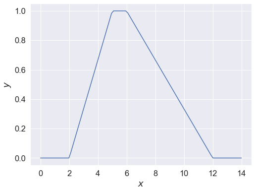

```python
plt.figure(figsize=(8,6))
plt.plot(x_list,y_list)
plt.xlabel('$x$');
plt.ylabel('$y$');
```

因此，我们把两个极大型指标保持不变，对极小型指标采用取倒数操作，对区间型指标使用上面介绍的处理方法。处理结果见下图。

[figure not shown]

**Step3**:无量纲处理。以 "人均专著" 属性为例，我们使用向量归一化方法：

$$ \begin{aligned} &0.1 / \sqrt{0.1^{2}+0.2^{2}+0.4^{2}+0.9^{2}+1.2^{2}}=0.0637576713063384\\ &0.2 / \sqrt{0.1^{2}+0.2^{2}+0.4^{2}+0.9^{2}+1.2^{2}}=0.12751534261266767\\ &0.4 / \sqrt{0.1^{2}+0.2^{2}+0.4^{2}+0.9^{2}+1.2^{2}}=0.2550306852253334\\ &\begin{array}{l} {0.9 / \sqrt{0.1^{2}+0.2^{2}+0.4^{2}+0.9^{2}+1.2^{2}}=0.5738190417570045} \\ {1.2 / \sqrt{0.1^{2}+0.2^{2}+0.4^{2}+0.9^{2}+1.2^{2}}=0.7650920556760059} \end{array} \end{aligned} $$

使用同样的向量归一化方法，我们可以对其他三个指标也进行无量纲化处理，得到如下表所示的结果

[figure not shown]

**Step4**: 选出其中的最优方案和最劣方案。

[figure not shown]

**Step5**: 计算每一个学校，与最优方案以及最劣方案之间的距离

$$ \begin{array}{l} {D_{i}^{+}=\sqrt{\sum_{j=1}^{m} w_{j}\left(Z_{j}^{+}-z_{i j}\right)^{2}}} \\ {D_{i}^{-}=\sqrt{\sum_{j=1}^{m} w_{j}\left(Z_{j}^{-}-z_{i j}\right)^{2}}} \end{array} $$

然后使用如下的评价函数将其综合起来

$$ C_{i}=\frac{D_{i}^{-}}{D_{i}^{+}+D_{i}^{-}} $$

思考 如果理想中最好的大学是真实存在的，其得分$C_i$应该等于几，为什么？如果是理想中最差的大学真实存在呢？

**Step6**: 最终评价结果如下

[figure not shown]

当然，直接看结果可能不够直观，我们来通过一张雷达图解释这个评价的结果。

```python
import plotly.graph_objects as go

categories = ['人均专著','生师比','科研经费','逾期毕业率']

fig = go.Figure()

fig.add_trace(go.Scatterpolar(
      r=[0.063758,0.597022,0.344901,0.275343],
      theta=categories,
      fill='toself',
      name='院校 A'
))
fig.add_trace(go.Scatterpolar(
      r=[0.127, 0.597,0.413,0.231],
      theta=categories,
      fill='toself',
      name='院校 B'
))

fig.add_trace(go.Scatterpolar(
      r=[0.255,0.497,0.482,0.193],
      theta=categories,
      fill='toself',
      name='院校 C'
))
```

```python
fig.add_trace(go.Scatterpolar(
      r=[0.573,0.199,0.689,0.562],
      theta=categories,
      fill='toself',
      name='院校 D'
))

fig.add_trace(go.Scatterpolar(
      r=[0.765,0,0.027,0.718],
      theta=categories,
      fill='toself',
      name='院校 E'
))


fig.update_layout(
  polar=dict(
    radialaxis=dict(
      visible=True,
#       range=[0, 5]
    )),
  showlegend=True
)
```

```python
fig
```

[interactive chart not shown]

计算的代码为

```python
import pandas as pd
import numpy as np

#极小型指标转极大型指标
def dataDirection_1(datas, offset=0):
 def normalization(data):
  return 1 / (data + offset)

 return list(map(normalization, datas))

#居中型指标转极大型指标
def dataDirection_2(datas, x_min, x_max):
 def normalization(data):
  if data <= x_min or data >= x_max:
   return 0
  elif data > x_min and data < (x_min + x_max) / 2:
   return 2 * (data - x_min) / (x_max - x_min)
  elif data < x_max and data >= (x_min + x_max) / 2:
   return 2 * (x_max - data) / (x_max - x_min)

 return list(map(normalization, datas))
```

```python
#区间型指标转极大型指标
def dataDirection_3(datas, x_min, x_max, x_minimum, x_maximum):
 def normalization(data):
  if data >= x_min and data <= x_max:
   return 1
  elif data <= x_minimum or data >= x_maximum:
   return 0
  elif data > x_max and data < x_maximum:
   return 1 - (data - x_max) / (x_maximum - x_max)
  elif data < x_min and data > x_minimum:
   return 1 - (x_min - data) / (x_min - x_minimum)

 return list(map(normalization, datas))

def topsis(data, weight=None):
 # 归一化
 data = data / np.sqrt((data ** 2).sum())

 # 最优最劣方案
 Z = pd.DataFrame([data.min(), data.max()], index=['负理想解', '正理想解'])

 # 距离
 weight = entropyWeight(data) if weight is None else np.array(weight)
 Result = data.copy()
 Result['正理想解'] = np.sqrt(((data - Z.loc['正理想解']) ** 2 * weight).sum(axis=1))
 Result['负理想解'] = np.sqrt(((data - Z.loc['负理想解']) ** 2 * weight).sum(axis=1))

 # 综合得分指数
 Result['综合得分指数'] = Result['负理想解'] / (Result['负理想解'] + Result['正理想解'])
 Result['排序'] = Result.rank(ascending=False)['综合得分指数']

 return Result, Z, weight
```

```python
data = pd.DataFrame(
    {'人均专著': [0.1, 0.2, 0.4, 0.9, 1.2], '生师比': [5, 6, 7, 10, 2], '科研经费': [5000, 6000, 7000, 10000, 400],
     '逾期毕业率': [4.7, 5.6, 6.7, 2.3, 1.8]}, index=['院校' + i for i in list('ABCDE')])

data['生师比'] = dataDirection_3(data['生师比'], 5, 6, 2, 12)   # 师生比数据为区间型指标
data['逾期毕业率'] = 1 / data['逾期毕业率']   # 逾期毕业率为极小型指标
Result, Z, weight = topsis(data, weight=[0.2, 0.3, 0.4, 0.1])    # 设置权系数
Result
```

|  | 人均专著 | 生师比 | 科研经费 | 逾期毕业率 | 正理想解 | 负理想解 | 综合得分指数 | 排序 |
| --- | --- | --- | --- | --- | --- | --- | --- | --- |
| 院校A | 0.063758 | 0.597022 | 0.344901 | 0.275343 | 0.406984 | 0.384552 | 0.485830 | 4.0 |
| 院校B | 0.127515 | 0.597022 | 0.413882 | 0.231092 | 0.368177 | 0.409360 | 0.526483 | 3.0 |
| 院校C | 0.255031 | 0.497519 | 0.482862 | 0.193151 | 0.315879 | 0.405565 | 0.562158 | 2.0 |
| 院校D | 0.573819 | 0.199007 | 0.689803 | 0.562658 | 0.239342 | 0.502968 | 0.677571 | 1.0 |
| 院校E | 0.765092 | 0.000000 | 0.027592 | 0.718952 | 0.531357 | 0.354994 | 0.400512 | 5.0 |

上面是通过举例来进行TOPSIS方法的实现，关于TOPSIS方法的更详细理论推导，参考[这里](https://wiki.mbalib.com/wiki/TOPSIS%E6%B3%95)。

在实际论文撰写的过程中，最好理论性强一些，而不是像我们上面一样简单地代入数据计算。

思考 上面的TOPSIS方法的权重已经给出，请思考，如果实际建模的时候没有给出权重，应该如何选取？

# Questions???

**参考文献**

- ThomsonRen 的 github https://github.com/ThomsonRen/mathmodels
- youcans Python小白的数学建模课 https://www.zhihu.com/column/c_1381900867424075776
- 司守奎 的 《Python数学实验与建模》